# K-Means - Iteration 3

# Iteration 3 - Discretized data

## 1. Load Libraries

```r
if (!require(pacman)) install.packages("pacman")
pacman::p_load(dplyr,factoextra, gridExtra, ggplot2,reshape2,cluster, RColorBrewer,tidyr)
```

## 2. Import necessary tables

```r
# import fct_features
fct_features <- read.csv("fct_features.csv")
head(fct_features)
```

|  | customer_unique_id | recency | frequency | monetary | target |
| --- | --- | --- | --- | --- | --- |
| 1 | 0000f46a3911fa3c0805444483337064 | 296 | 1 | 69.00 | 0 |
| 2 | 0000f6ccb0745a6a4b88665a16c9f078 | 80 | 1 | 25.99 | 0 |
| 3 | 0004aac84e0df4da2b147fca70cf8255 | 47 | 1 | 180.00 | 0 |
| 4 | 0005e1862207bf6ccc02e4228effd9a0 | 302 | 1 | 135.00 | 0 |
| 5 | 0006fdc98a402fceb4eb0ee528f6a8d4 | 166 | 1 | 13.90 | 0 |
| 6 | 00082cbe03e478190aadbea78542e933 | 42 | 1 | 79.00 | 0 |

```r
NA
```

## 3. EDA

### 3.1. Check dataframe

```r
str(fct_features)
```

```
'data.frame':   43500 obs. of  5 variables:
 $ customer_unique_id: chr  "0000f46a3911fa3c0805444483337064" "0000f6ccb0745a6a4b88665a16c9f078" "0004aac84e0df4da2b147fca70cf8255" "0005e1862207bf6ccc02e4228effd9a0" ...
 $ recency           : int  296 80 47 302 166 42 142 93 19 136 ...
 $ frequency         : int  1 1 1 1 1 1 1 1 1 1 ...
 $ monetary          : num  69 26 180 135 13.9 ...
 $ target            : int  0 0 0 0 0 0 0 0 0 0 ...
```

### 3.2 Summary

```r
summary(fct_features)
```

```
 customer_unique_id    recency        frequency        monetary            target
 Length:43500       Min.   :  0.0   Min.   :1.000   Min.   :    2.29   Min.   :0.00000
 Class :character   1st Qu.: 48.0   1st Qu.:1.000   1st Qu.:   49.00   1st Qu.:0.00000
 Mode  :character   Median :124.0   Median :1.000   Median :   89.90   Median :0.00000
                    Mean   :139.3   Mean   :1.031   Mean   :  150.06   Mean   :0.01559
                    3rd Qu.:215.0   3rd Qu.:1.000   3rd Qu.:  159.90   3rd Qu.:0.00000
                    Max.   :483.0   Max.   :6.000   Max.   :13440.00   Max.   :1.00000
```

### 3.3 Missing values

```r
#There is no missing value
colSums(is.na(fct_features)) %>% as.data.frame
```

|  | . |
| --- | --- |
| customer_unique_id | 0 |
| recency | 0 |
| frequency | 0 |
| monetary | 0 |
| target | 0 |

**Comments:** No missing values were found.

### 3.4 Distribution of variables’ values (Histogram)

#### 3.4.1 fct_features

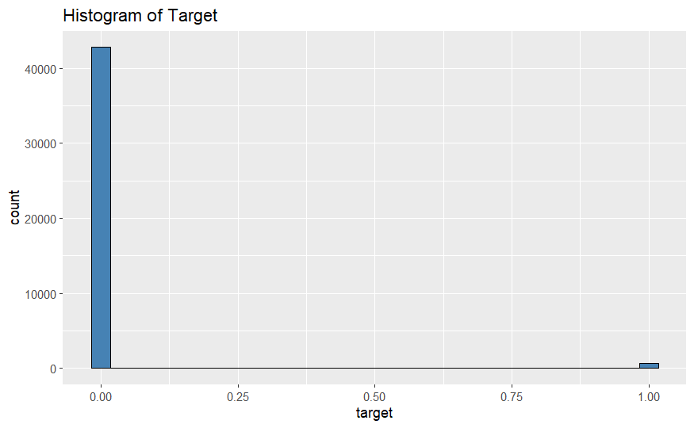

```r
ggplot(data=fct_features, aes(x=target)) +
 geom_histogram(fill="steelblue", color="black", bin=40) +
  ggtitle("Histogram of Target")
```

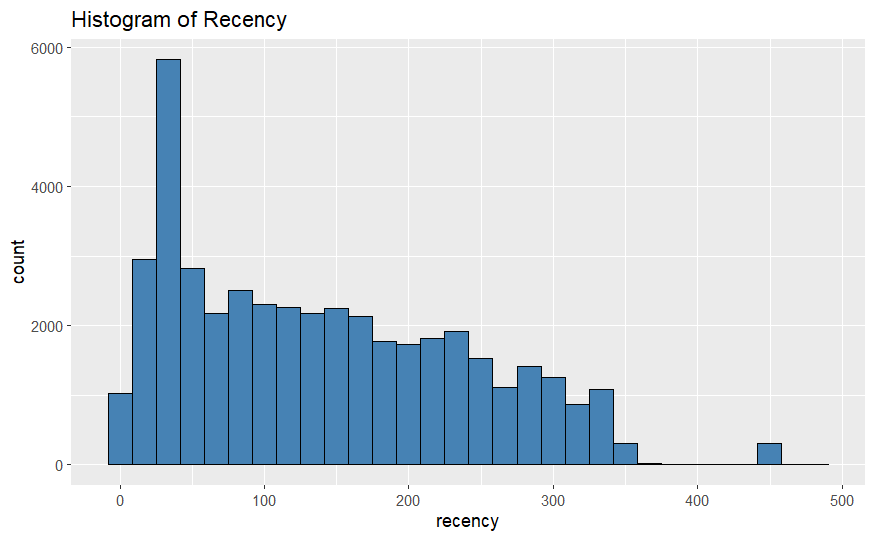

```r
ggplot(data=fct_features, aes(x=recency)) +
  geom_histogram(fill="steelblue", color="black", bin=40) +
  ggtitle("Histogram of Recency")
```

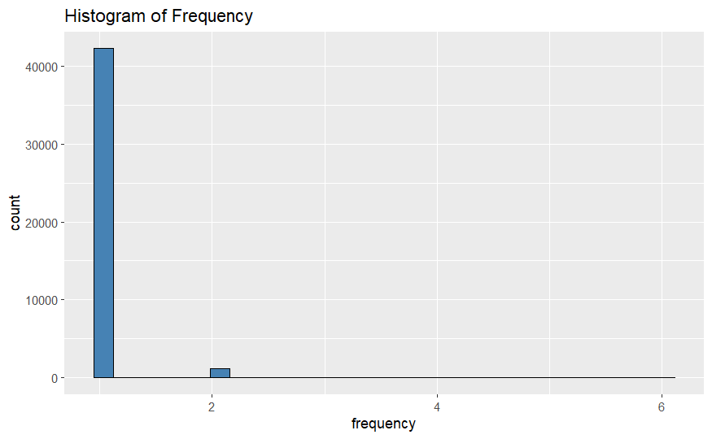

```r
ggplot(data=fct_features, aes(x=frequency)) +
  geom_histogram(fill="steelblue", color="black", bin=40) +
  ggtitle("Histogram of Frequency")
```

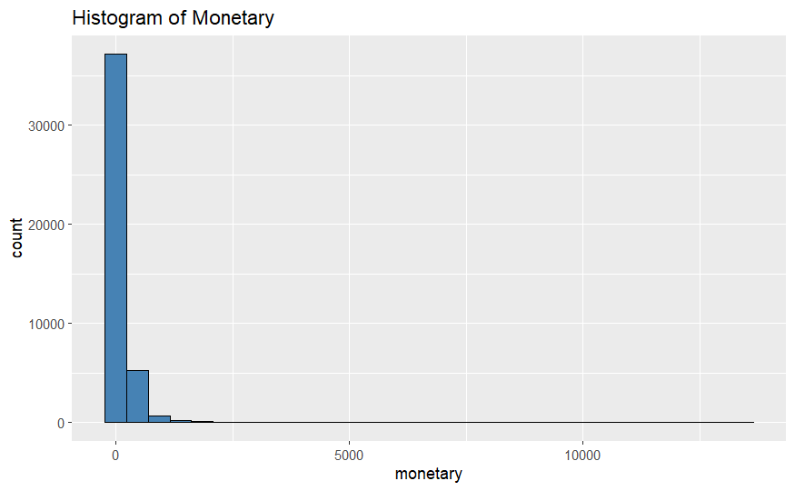

```r
ggplot(data=fct_features, aes(x=monetary)) +
  geom_histogram(fill="steelblue", color="black", bin=40) +
  ggtitle("Histogram of Monetary")
```

### 3.5 Distribution of variables’ values (Boxplot)

#### 3.5.1 fct_features

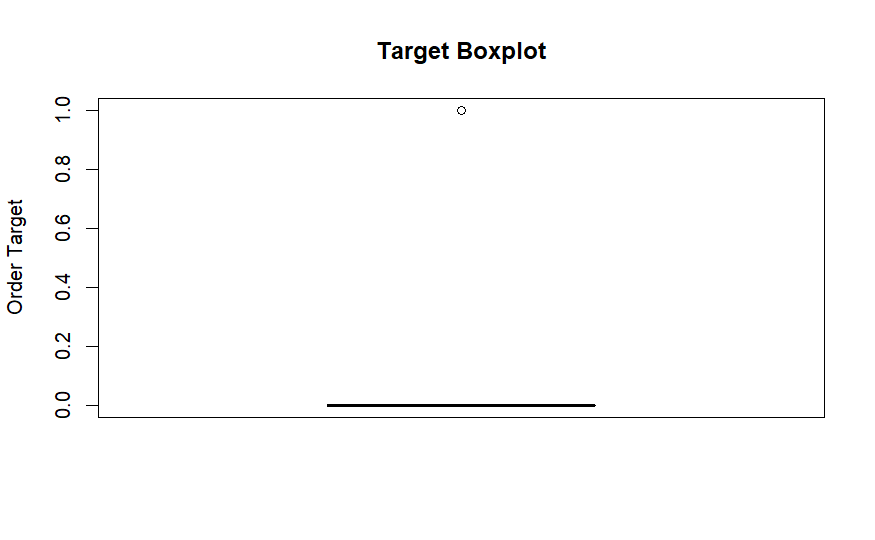

```r
boxplot(fct_features$target,
        ylab = "Order Target",
        main="Target Boxplot")
```

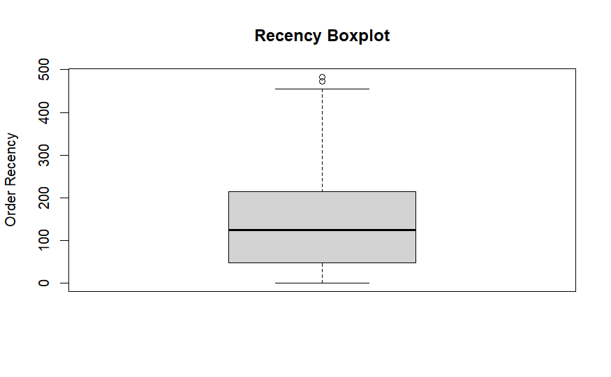

```r
boxplot(fct_features$recency,
        ylab = "Order Recency",
        main="Recency Boxplot")
```

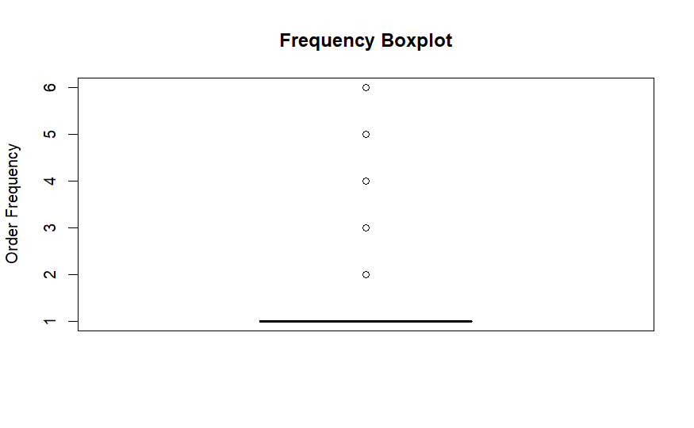

```r
boxplot(fct_features$frequency,
        ylab = "Order Frequency",
        main="Frequency Boxplot")
```

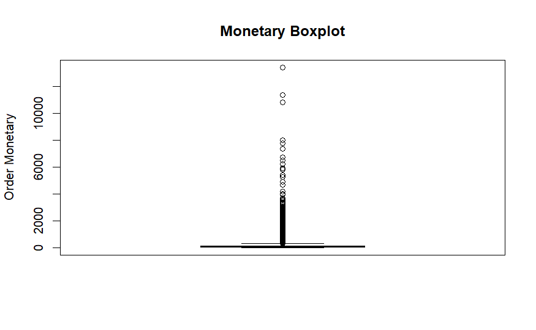

```r
boxplot(fct_features$monetary,
        ylab = "Order Monetary",
        main="Monetary Boxplot")
```

**Comments:** It is possible to confirm the skewness of data distribution observed in the histograms, and also the presence of outliers that vary from few observations (target, recency, and frequency) to an higg number (monetary). This can in turn influence the performance of Machine Learning (ML) algorithms.

### 3.6 Selecting RFM features only

```r
fct_rfm<- fct_features %>% select('recency','monetary','frequency')
head(fct_rfm)
```

|  | recency | monetary | frequency |
| --- | --- | --- | --- |
| 1 | 296 | 69.00 | 1 |
| 2 | 80 | 25.99 | 1 |
| 3 | 47 | 180.00 | 1 |
| 4 | 302 | 135.00 | 1 |
| 5 | 166 | 13.90 | 1 |
| 6 | 42 | 79.00 | 1 |

## 4.Standardizing features

**Comments:** As the k-means algorithm is sensitive to the scale of the variables (more weight to variables with larger scales), was decided to discretize recency and monetary to help reduce this sensitivity, making the data more comparable with frequency

### 4.1 Using quartiles to create bins

```r
# Calculating quartiles to identify cut-off values
quartiles_recency <- quantile(fct_rfm$recency, c(0, 0.25, 0.5, 0.75, 1))

quartiles_monetary <-quantile(fct_rfm$monetary, c(0, 0.25, 0.5, 0.75, 1))

data.frame(recency=quartiles_recency, monetary=quartiles_monetary %>% round(0))
```

|  | recency | monetary |
| --- | --- | --- |
| 0% | 0 | 2 |
| 25% | 48 | 49 |
| 50% | 124 | 90 |
| 75% | 215 | 160 |
| 100% | 483 | 13440 |

```r
NA
```

### 4.2 Features’ discretization

```r
#We put the features as an integer so that it can be used in the model
recency_trans<-
  cut(fct_features$recency, breaks = quartiles_recency,
      labels = c("1", "2", "3", "4"), include.lowest = TRUE) %>% as.integer()


monetary_trans<-
  cut(fct_features$monetary, breaks = quartiles_monetary,
      labels = c("1", "2", "3", "4"), include.lowest = TRUE) %>% as.integer()
```

### 4.3 Creating new features and selecting them

```r
fct_rfm <- fct_rfm %>% mutate(
  recency_disc=recency_trans,
  monetary_disc=monetary_trans) %>% select('frequency','recency_disc','monetary_disc')
head(fct_rfm)
```

|  | frequency | recency_disc | monetary_disc |
| --- | --- | --- | --- |
| 1 | 1 | 4 | 2 |
| 2 | 1 | 2 | 1 |
| 3 | 1 | 1 | 4 |
| 4 | 1 | 4 | 3 |
| 5 | 1 | 3 | 1 |
| 6 | 1 | 1 | 2 |

### 4.4 Distribution of variables’ values (Bar Plot)

#### 4.4.1 Features discretized

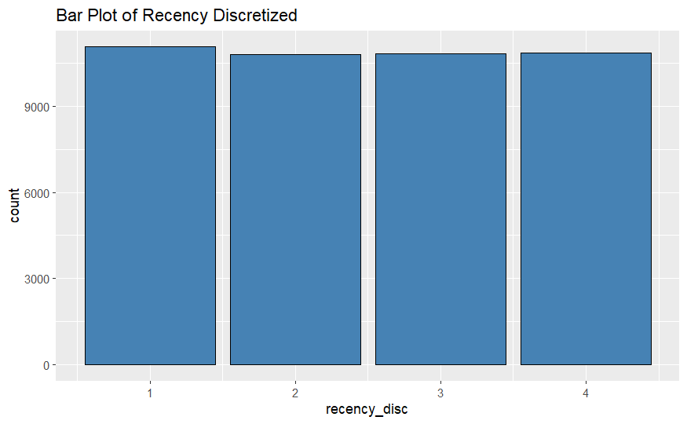

```r
#The discretized variables show approximately the same number of observations, while the frequency variable shows a greater number of observations in class 1
ggplot(data=fct_rfm, aes(x=recency_disc)) +
  geom_bar(fill="steelblue", color="black", bin=40) +
  ggtitle("Bar Plot of Recency Discretized")
```

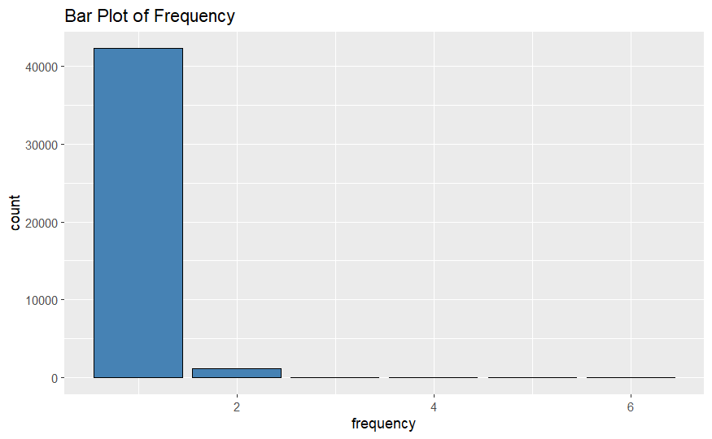

```r
ggplot(data=fct_rfm, aes(x=frequency)) +
  geom_bar(fill="steelblue", color="black", bin=40) +
  ggtitle("Bar Plot of Frequency")
```

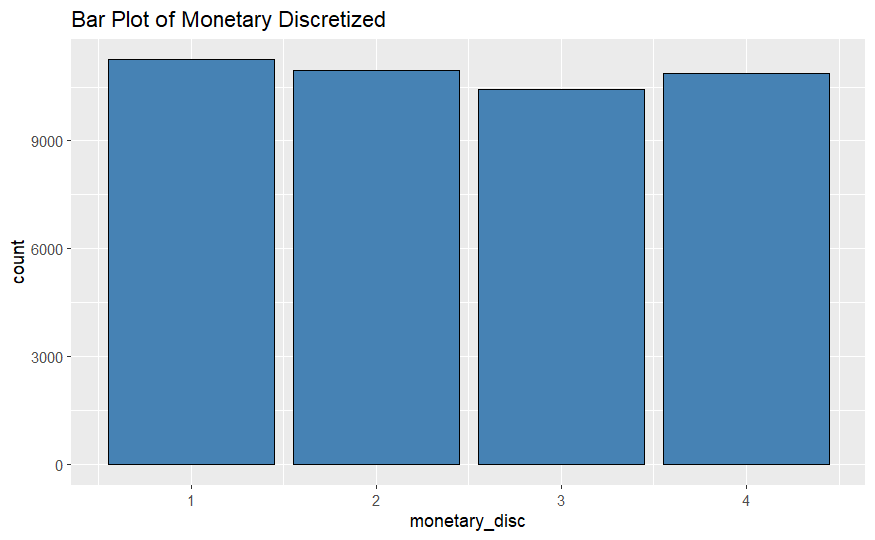

```r
ggplot(data=fct_rfm, aes(x=monetary_disc)) +
  geom_bar(fill="steelblue", color="black", bin=40) +
  ggtitle("Bar Plot of Monetary Discretized")
```

**Comments:** The discretized variables show approximately the same number of observations, while the frequency variable shows a greater number of observations in class 1

### 4.5 Distribution of variables’ values (Boxplot)

#### 4.5.1 Features discretized

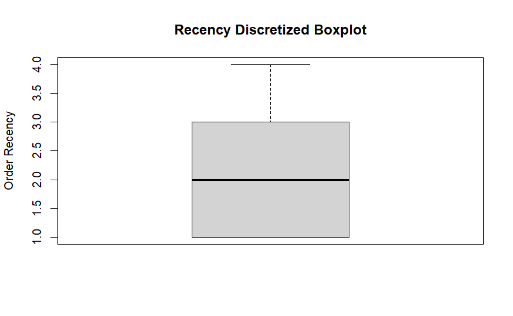

```r
boxplot(fct_rfm$recency_disc,
        ylab = "Order Recency",
        main="Recency Discretized Boxplot")
```

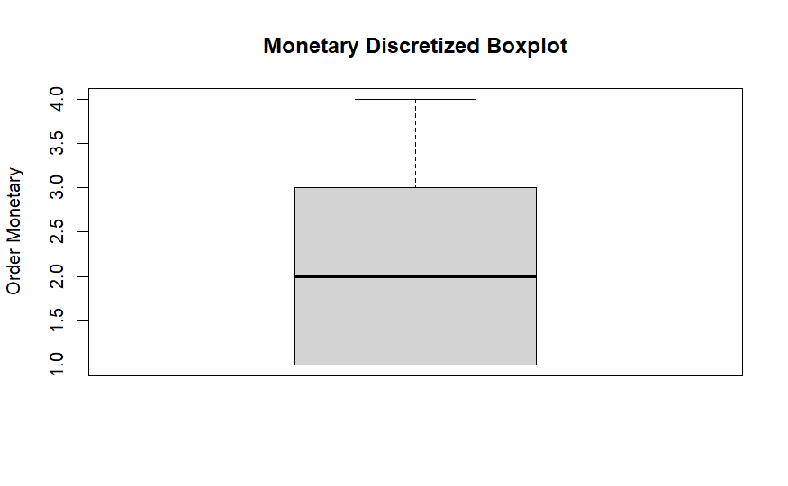

```r
boxplot(fct_rfm$monetary_disc,
        ylab = "Order Monetary",
        main="Monetary Discretized Boxplot")
```

**Comments:** Outliers were removed from the transformed variables

## 5. Sampling

```r
#We going to use more than 10% dataset in our sample
seed<-1234
set.seed(seed)

features_sample <- sample_n(fct_rfm, 5000)
head(features_sample)
```

|  | frequency | recency_disc | monetary_disc |
| --- | --- | --- | --- |
| 1 | 1 | 3 | 3 |
| 2 | 1 | 1 | 3 |
| 3 | 1 | 4 | 4 |
| 4 | 1 | 2 | 2 |
| 5 | 2 | 3 | 4 |
| 6 | 1 | 3 | 3 |

## 6.Determine Number of Clusters

### 6.1 “Elbow method”

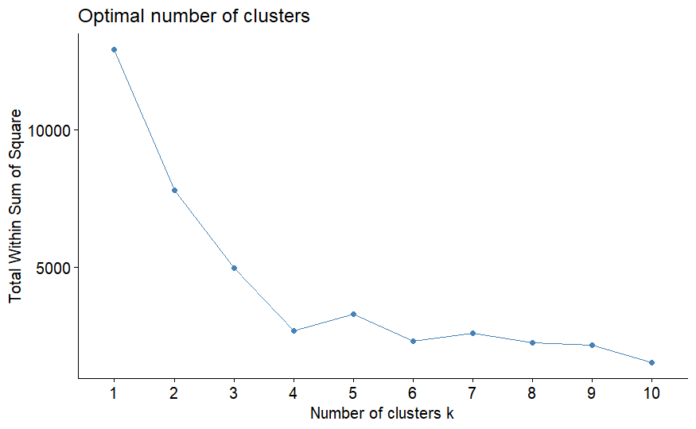

```r
elbow_plot<- factoextra::fviz_nbclust(features_sample, kmeans, method = "wss")

elbow_plot
```

**Comments:** 4 clusters

### 6.2 “Silhouette-score method”

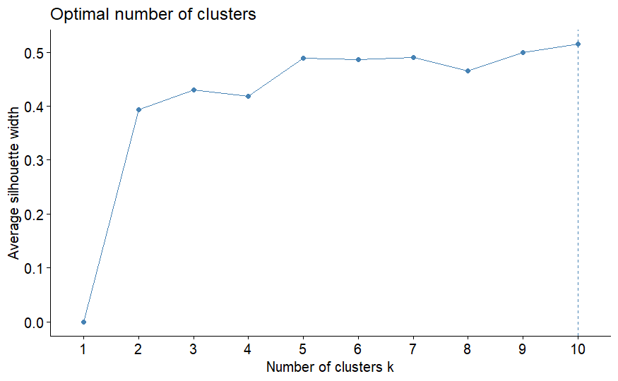

```r
silhouette_plot <- factoextra::fviz_nbclust(features_sample, kmeans, method = "silhouette")

silhouette_plot
```

**Comments:** 10 clusters

### 6.3 “Gap Statistic Method”

```r
gap_plot<-factoextra::fviz_nbclust(features_sample, kmeans, method = "gap_stat")
```

```
Clustering k = 1,2,..., K.max (= 10): .. done
Bootstrapping, b = 1,2,..., B (= 100)  [one "." per sample]:
......................................
```

```
............ 50
...................
```

```
.......
```

```
........................ 100
```

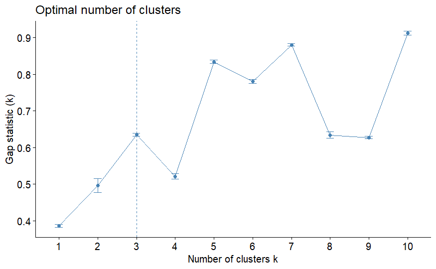

```r
gap_plot
```

**Comments:** 3 clusters

### 6.4.Comparing k recommendations

#### 6.4.1 Using samples to perform k-means

```r
kmeans_sample_3 <- kmeans(features_sample, centers = 3)
kmeans_sample_4 <- kmeans(features_sample, centers = 4)
kmeans_sample_10 <- kmeans(features_sample, centers = 10)
```

#### 6.4.2 Use inertia and the silhouette score to analyse k recommendations

##### 6.4.2.1 Calculate the inertia (within-cluster sum of squares) for each model

```r
inertia_kmeans_sample_3 <- kmeans_sample_3$tot.withinss
inertia_kmeans_sample_4 <- kmeans_sample_4$tot.withinss
inertia_kmeans_sample_10 <- kmeans_sample_10$tot.withinss
```

##### 6.4.2.2 Calculate the silhouette score for each model

```r
silhouette_kmeans_sample_3 <- silhouette(kmeans_sample_3$cluster, dist(features_sample))
silhouette_kmeans_sample_4 <- silhouette(kmeans_sample_4$cluster, dist(features_sample))
silhouette_kmeans_sample_10 <- silhouette(kmeans_sample_10$cluster, dist(features_sample))
```

#### 6.4.3 Results

```r
cat("Inertia - 3 clusters:", inertia_kmeans_sample_3)
```

```
Inertia - 3 clusters: 5057.386
```

```r
cat("Inertia - 4 clusters:", inertia_kmeans_sample_4)
```

```
Inertia - 4 clusters: 2691.857
```

```r
cat("Inertia - 10 clusters:", inertia_kmeans_sample_10)
```

```
Inertia - 10 clusters: 1737.091
```

```r
cat("Silhouette score - 3 clusters:", mean(silhouette_kmeans_sample_3[, "sil_width"]))
```

```
Silhouette score - 3 clusters: 0.4159362
```

```r
cat("Silhouette score - 4 clusters:", mean(silhouette_kmeans_sample_4[, "sil_width"]))
```

```
Silhouette score - 4 clusters: 0.523609
```

```r
cat("Silhouette score - 10 clusters:", mean(silhouette_kmeans_sample_10[, "sil_width"]))
```

```
Silhouette score - 10 clusters: 0.5013594
```

**Comments:** Based on the previous analysis, K=3 inertia value is higher and the silhouette score is lower - not chosen. So, was chosen k=10 because it has a much smaller inertia value than k=4 and only a slightly lower score.

### 6.5 Define number of clusters

```r
k_clusters <- which(silhouette_plot$data$y == max(silhouette_plot$data$y))

k_clusters
```

```
[1] 10
```

## 7. Apply K-means algorithm

```r
set.seed(seed)
fit.kmeans <- kmeans(fct_rfm, centers = k_clusters)

fit.kmeans
```

```
K-means clustering with 10 clusters of sizes 9965, 113, 5101, 10956, 5378, 5479, 56, 520, 168, 5764

Cluster means:
   frequency recency_disc monetary_disc
1   1.000000     3.515504      3.508781
2   2.115044     3.504425      1.716814
3   1.000000     2.000000      3.507744
4   1.009858     1.492150      1.500913
5   1.000000     3.465787      2.000000
6   1.048366     1.000000      3.492243
7   3.321429     1.625000      3.910714
8   2.040385     2.498077      3.661538
9   2.065476     4.000000      3.660714
10  1.000000     3.514747      1.000000

```

[output cut: 48 more lines]

## 8. Visualization clusters

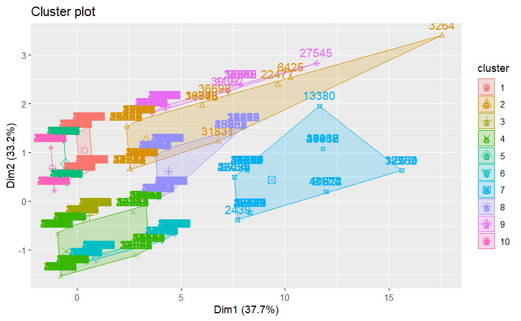

```r
factoextra::fviz_cluster(fit.kmeans, data = fct_rfm)
```

## 9. Create a segmentation with 10 clusters

```r
#Create a column
fct_features$cluster <- fit.kmeans$cluster

#How many customers in each cluster?
table(fct_features$cluster)
```

```
    1     2     3     4     5     6     7     8     9    10
 9965   113  5101 10956  5378  5479    56   520   168  5764
```

```r
#Dataset with iteration segmentation.
fct_features %>% select('customer_unique_id','cluster') %>% head()
```

|  | customer_unique_id | cluster |
| --- | --- | --- |
| 1 | 0000f46a3911fa3c0805444483337064 | 5 |
| 2 | 0000f6ccb0745a6a4b88665a16c9f078 | 4 |
| 3 | 0004aac84e0df4da2b147fca70cf8255 | 6 |
| 4 | 0005e1862207bf6ccc02e4228effd9a0 | 1 |
| 5 | 0006fdc98a402fceb4eb0ee528f6a8d4 | 10 |
| 6 | 00082cbe03e478190aadbea78542e933 | 4 |

```r
NA
```

## 10. Table with cluster means x features

```r
centers<-data.frame(fit.kmeans$centers)
centers
```

|  | frequency | recency_disc | monetary_disc |
| --- | --- | --- | --- |
| 1 | 1.000000 | 3.515504 | 3.508781 |
| 2 | 2.115044 | 3.504425 | 1.716814 |
| 3 | 1.000000 | 2.000000 | 3.507744 |
| 4 | 1.009858 | 1.492150 | 1.500913 |
| 5 | 1.000000 | 3.465787 | 2.000000 |
| 6 | 1.048366 | 1.000000 | 3.492243 |
| 7 | 3.321429 | 1.625000 | 3.910714 |
| 8 | 2.040385 | 2.498077 | 3.661538 |
| 9 | 2.065476 | 4.000000 | 3.660714 |
| 10 | 1.000000 | 3.514747 | 1.000000 |

## 11.Ploting clusters means

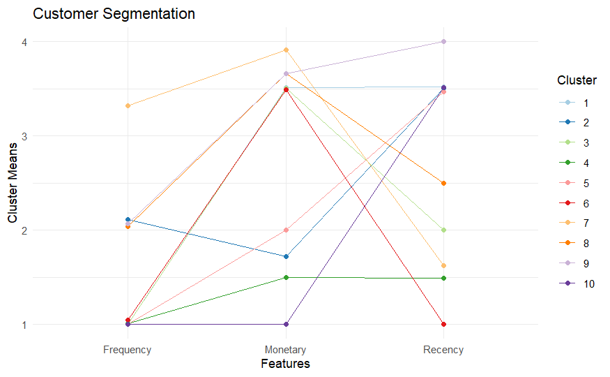

```r
#Create cluster column
centers$cluster<-as.numeric(1:10)

#Cluster column first of all
centers <- centers[, c("cluster", names(centers)[-which(names(centers) == "cluster")])]

#Rename columns
names(centers)[1:4] <-  c("Cluster", "Frequency", "Recency", "Monetary")

#Transform in pivot longer
df_long <- pivot_longer(centers, cols = -Cluster, names_to = "Feature", values_to = "Value")


ggplot(df_long, aes(x = Feature, y = Value, group = Cluster, color = as.factor(Cluster))) +
  geom_line() +
  geom_point() +
  labs(x = "Features", y = "Cluster Means", title = "Customer Segmentation",color = "Cluster") +
  scale_color_brewer(palette = "Paired")+
  theme_minimal()
```

```r
NA
NA
```

## 12. Iteration Conclusions

- In this iteration, was decided to discretize the variables in order to reduce the model’s sensitivity to variables with larger scales and, to try obtain a better frequency differentiation. To do this, was used the quartile values;
- According to k recommendations analysis, was opted to use a k=10. However, compared to the last iteration, the inertia value of k selected increased, suggesting the data points within each cluster are less close to their respective centroids. On the other hand, the silhouette score increased, i.e, the data points are better well-matched to its assigned cluster;
- Thus, with k=10 was possible to conclude:
  - A discrepancy in the value of clusters compared to previous iterations;
  - Better general customer segmentation, specially in terms of frequency;
  - Better understanding of the most and least valuable groups and the strategies to apply to each:
    - Cluster 1 - Peekaboo - campaigns that increase the frequency of orders and decrease the time since the last one;
    - Cluster 2 - Opportunity seekers - focus on increasing the amount spent and decreasing the time since the last order;
    - Cluster 3 - New peekaboo - campaigns to keep recency low and increase frequency;
    - Cluster 4 - Curious - new customers - spend little and only a few times - boost the number of orders and increase the amount invested;
    - Cluster 5 - Almost lost - not as bad as cluster 10, but working towards the same goal;
    - Cluster 6 - New golden goose - more recent buyers, with high values - focus on the number of orders (they only place a few);
    - Cluster 7 - Golden goose - more loyal customers - we care campaigns;
    - Cluster 8 - Former golden goose - campaigns to turn them into golden goose, preventing them from becoming almost lost;
    - Cluster 9 - Underdogs - focus on reducing the time since their last order - they have everything it takes to become golden goose;
    - Cluster 10 - Uninterested/lost - campaigns that work on all the RFM components;
- In this iteration, was possible to differentiate the clusters in great detail with regard to their behavior in relation to the RFM variables, specially in terms of frequency.